# Capstone Quiz I

Complete all **Exercises**, and submit answers to **Questions** on the Coursera platform.

```r
library(devtools)
library("dplyr")
```

```r
library("statsr")
library(ggplot2)
library(gridExtra)
library(MASS)
```

This initial quiz will concern exploratory data analysis (EDA) of the Ames Housing dataset. EDA is essential when working with any source of data and helps inform modeling.

First, let us load the data:

```r
load("ames_train.Rdata")
```

1. Which of the following are the three variables with the highest number of missing observations?
   1. `Misc.Feature`, `Fence`, `Pool.QC`
   2. `Misc.Feature`, `Alley`, `Pool.QC`
   3. `Pool.QC`, `Alley`, `Fence`
   4. `Fireplace.Qu`, `Pool.QC`, `Lot.Frontage`

```r
# type your code for Question 1 here, and Knit
sapply(ames_train, function(x) sum(is.na(x)))
```

```
##             PID            area           price     MS.SubClass       MS.Zoning
##               0               0               0               0               0
##    Lot.Frontage        Lot.Area          Street           Alley       Lot.Shape
##             167               0               0             933               0
##    Land.Contour       Utilities      Lot.Config      Land.Slope    Neighborhood
##               0               0               0               0               0
##     Condition.1     Condition.2       Bldg.Type     House.Style    Overall.Qual
##               0               0               0               0               0
##    Overall.Cond      Year.Built  Year.Remod.Add      Roof.Style       Roof.Matl
##               0               0               0               0               0
##    Exterior.1st    Exterior.2nd    Mas.Vnr.Type    Mas.Vnr.Area      Exter.Qual
##               0               0               0               7               0
##      Exter.Cond      Foundation       Bsmt.Qual       Bsmt.Cond   Bsmt.Exposure
##               0               0              21              21              21
##  BsmtFin.Type.1    BsmtFin.SF.1  BsmtFin.Type.2    BsmtFin.SF.2     Bsmt.Unf.SF
##              21               1              21               1               1
##   Total.Bsmt.SF         Heating      Heating.QC     Central.Air      Electrical
##               1               0               0               0               0
##     X1st.Flr.SF     X2nd.Flr.SF Low.Qual.Fin.SF  Bsmt.Full.Bath  Bsmt.Half.Bath
##               0               0               0               1               1
##       Full.Bath       Half.Bath   Bedroom.AbvGr   Kitchen.AbvGr    Kitchen.Qual
##               0               0               0               0               0
##   TotRms.AbvGrd      Functional      Fireplaces    Fireplace.Qu     Garage.Type
##               0               0               0             491              46
##   Garage.Yr.Blt   Garage.Finish     Garage.Cars     Garage.Area     Garage.Qual
##              48              46               1               1              47
##     Garage.Cond     Paved.Drive    Wood.Deck.SF   Open.Porch.SF  Enclosed.Porch
##              47               0               0               0               0
##     X3Ssn.Porch    Screen.Porch       Pool.Area         Pool.QC           Fence
##               0               0               0             997             798
##    Misc.Feature        Misc.Val         Mo.Sold         Yr.Sold       Sale.Type
##             971               0               0               0               0
##  Sale.Condition
##               0
```

2. How many categorical variables are coded in R as having type `int`? Change them to factors when conducting your analysis.
   1. 0
   2. 1
   3. 2
   4. 3

```r
# type your code for Question 2 here, and Knit
ames_train$Overall.Qual<- factor(ames_train$Overall.Qual, ordered = TRUE)
ames_train$Overall.Cond<-factor(ames_train$Overall.Cond, ordered = TRUE)
```

3. In terms of price, which neighborhood has the highest standard deviation?
   1. `StoneBr`
   2. `Timber`
   3. `Veenker`
   4. `NridgHt`

```r
# type your code for Question 3 here, and Knit
ames_train %>% group_by(Neighborhood) %>% summarise(sd=sd(price)) %>% arrange(desc(sd))
```

```
## # A tibble: 27 x 2
##    Neighborhood      sd
##    <fct>          <dbl>
##  1 StoneBr      123459.
##  2 NridgHt      105089.
##  3 Timber        84030.
##  4 Veenker       72545.
##  5 Crawfor       71268.
##  6 GrnHill       70711.
##  7 Somerst       65199.
##  8 Edwards       54852.
##  9 CollgCr       52786.
## 10 SawyerW       48354.
## # ... with 17 more rows
```

4. Using scatter plots or other graphical displays, which of the following variables appears to be the best single predictor of `price`?
   1. `Lot.Area`
   2. `Bedroom.AbvGr`
   3. `Overall.Qual`
   4. `Year.Built`

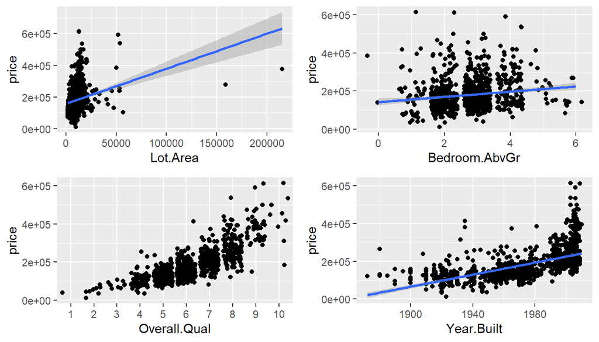

```r
# type your code for Question 4 here, and Knit
plot1 <- ggplot(ames_train, aes(y=price, x=Lot.Area))+geom_point()+geom_smooth(method="lm")
plot2 <- ggplot(ames_train, aes(y=price, x=Bedroom.AbvGr))+geom_jitter()+geom_smooth(method="lm")
plot3 <-ggplot(ames_train, aes(y=price, x=Overall.Qual))+geom_jitter()+geom_smooth(method = "lm")
plot4 <-ggplot(ames_train, aes(y=price, x=Year.Built))+geom_point()+geom_smooth(method="lm")
grid.arrange(plot1,plot2,plot3,plot4, ncol=2)
```

5. Suppose you are examining the relationship between `price` and `area`. Which of the following variable transformations makes the relationship appear to be the most linear?
   1. Do not transform either `price` or `area`
   2. Log-transform `price` but not `area`
   3. Log-transform `area` but not `price`
   4. Log-transform both `price` and `area`

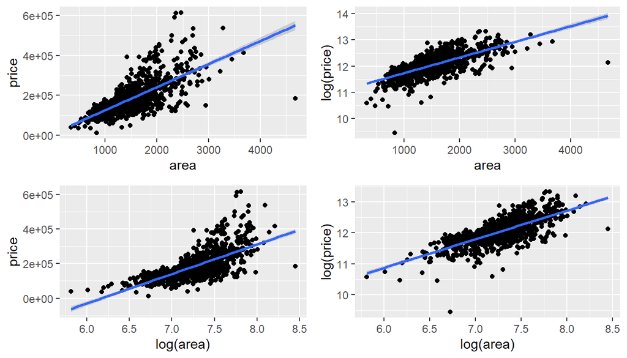

```r
# type your code for Question 5 here, and Knit
plot1 <- ggplot(ames_train, aes(y=price, x=area))+geom_point()+geom_smooth(method = "lm")
plot2 <- ggplot(ames_train, aes(y=log(price), x=area))+geom_jitter()+geom_smooth(method = "lm")
plot3 <- ggplot(ames_train, aes(y=price, x=log(area)))+geom_jitter()+geom_smooth(method = "lm")
plot4 <- ggplot(ames_train, aes(y=log(price), x=log(area)))+geom_point()+geom_smooth(method = "lm")
grid.arrange(plot1, plot2, plot3, plot4, ncol=2)
```

6. Suppose that your prior for the proportion of houses that have at least one garage is Beta(9, 1). What is your posterior? Assume a beta-binomial model for this proportion.
   1. Beta(954, 46)
   2. Beta(963, 46)
   3. Beta(954, 47)
   4. Beta(963, 47)

```r
# type your code for Question 6 here, and Knit
x <- ames_train %>% filter(Garage.Cars >=1) %>% summarise(Garage.Cars.ge1=n())
n <- ames_train %>% filter(!is.na(Garage.Cars)) %>% summarise(Garage.Cars.ge1=n())
print(paste("Beta(",9+x," ",1+n-x,")"))
```

```
## [1] "Beta( 962   47 )"
```

7. Which of the following statements is true about the dataset?
   1. Over 30 percent of houses were built after the year 1999.
   2. The median housing price is greater than the mean housing price.
   3. 21 houses do not have a basement.
   4. 4 houses are located on gravel streets.

```r
# type your code for Question 7 here, and Knit
ames_train %>% filter(Year.Built>199)%>% summarise(yr_built_199=n())
```

```
## # A tibble: 1 x 1
##   yr_built_199
##          <int>
## 1         1000
```